# Focused Neural-Behavior Validation and Artifact Screening

This notebook follows up on the strongest findings from the previous analysis:

- **HL17**, left ventral anterior insula:
  - Ordered mean movement-related HFB: about -1.51 dB
  - Pseudorandom mean movement-related HFB: about +0.55 dB
  - Pseudorandom minus Ordered: about +2.07 dB
- **IL11**, left posterior insula:
  - strongest target-direction candidate
  - circular-model R² about 0.216
  - preferred direction about 177 degrees
  - FDR q about 0.018
- **Global movement effect**:
  - 198/202 contacts had negative mean HFB change
  - median channel correlation with global HFB was high
  - 120 Hz line-noise power also decreased around movement
  - many effects survived adjacent-contact bipolar rereferencing

The purpose of this notebook is not to search broadly again. It asks whether the two interesting channels still look convincing after increasingly strict checks.

## Main questions

1. Does HL17 still distinguish Ordered and Pseudorandom trials after:
   - removing global HFB fluctuations
   - controlling for trial number / recording drift
   - controlling for pupil size and behavioral timing
   - excluding artifact-like trials
   - bipolar rereferencing
2. Does IL11 still show target-direction tuning after:
   - fitting the target circle more accurately
   - comparing the recorded `TargetAngle` with X/Y geometry
   - removing global HFB fluctuations
   - excluding artifact-like trials
   - bipolar rereferencing
3. Do raw traces, spectra, line-noise measurements, or neighboring contacts suggest an obvious artifact?

This remains exploratory. A result that survives these checks is more convincing, but still requires replication and contact-level imaging localization.

```python
from pathlib import Path
import re
import warnings

import matplotlib.pyplot as plt
import numpy as np
import pandas as pd

from scipy.signal import (
    welch,
    butter,
    sosfiltfilt,
    hilbert,
    iirnotch,
    filtfilt,
    stft,
)
from scipy.stats import (
    ttest_ind,
    spearmanr,
    t as t_distribution,
    f as f_distribution,
)

from BCI2000Tools.FileReader import bcistream

pd.set_option("display.max_columns", 140)
pd.set_option("display.width", 180)
pd.set_option("display.max_rows", 120)

RNG = np.random.default_rng(42)
```

## 1. Select and load the BCI2000 recording

```python
DAT_PATH = Path(
    r"C:\Users\gabri\Desktop\joystick_test_env\python_da\patient_data\ECOGS001R02.dat"
)

if not DAT_PATH.is_file():
    raise FileNotFoundError(
        f"File not found: {DAT_PATH}\n"
        "Edit DAT_PATH so it points to the correct BCI2000 .dat file."
    )

stream = bcistream(str(DAT_PATH))

core_states = [
    "TaskCondition",
    "TaskBlockType",
    "TaskBlock",
    "TaskTrial",
    "TargetAngle",
    "TargetX",
    "TargetY",
    "MovementStarted",
    "TargetHit",
    "Introduction",
    "PracticeTrial",
    "ReactionTimeMs",
    "MovementTimeMs",
    "TotalTimeMs",
    "JoystickXpos",
    "JoystickYpos",
]

eye_states = [
    name
    for name in stream.statedefs.keys()
    if ("eye" in name.lower() or "gaze" in name.lower())
]

requested_states = list(dict.fromkeys(core_states + eye_states))

available_states = [
    name for name in requested_states
    if name in stream.statedefs
]

signal_raw, decoded_states = stream.decode(
    nsamp="all",
    states=available_states,
)

signal_raw = np.asarray(signal_raw)

n_channels = int(stream.nchan)
n_samples = int(stream.samples())
fs = float(stream.samplingfreq_hz)

if signal_raw.shape == (n_channels, n_samples):
    signal = signal_raw.T
elif signal_raw.shape == (n_samples, n_channels):
    signal = signal_raw
else:
    raise ValueError(
        f"Unexpected signal shape: {signal_raw.shape}"
    )

states = {
    name: np.asarray(decoded_states[name]).ravel()
    for name in available_states
}

print(f"File:          {DAT_PATH.resolve()}")
print(f"Signal shape:  {signal.shape}")
print(f"Sampling rate: {fs:g} Hz")
print(f"Duration:      {n_samples / fs / 60:.2f} min")
print(f"States loaded: {len(states)}")
```

```
File:          C:\Users\gabri\Desktop\joystick_test_env\python_da\patient_data\ECOGS001R02.dat
Signal shape:  (1255100, 256)
Sampling rate: 2000 Hz
Duration:      10.46 min
States loaded: 34
```

## 2. Map intracranial channels to electrode targets

```python
channel_names = [
    str(name).strip()
    for name in stream.params["ChannelNames"]
]

implant_targets = {
    "AL": "L temporal pole",
    "BL": "L amygdala",
    "CL": "L hippocampal head",
    "DL": "L hippocampal tail",
    "EL": "L fusiform",
    "FL": "L orbitofrontal",
    "GL": "L opercular",
    "HL": "L anterior insula ventral",
    "IL": "L posterior insula",
    "AR": "R temporal pole",
    "BR": "R amygdala",
    "CR": "R hippocampal head",
    "DR": "R hippocampal tail",
    "ER": "R fusiform",
    "FR": "R orbitofrontal",
    "GR": "R opercular",
    "HR": "R anterior insula ventral",
    "IR": "R posterior insula",
}

rows = []

for signal_index, name in enumerate(channel_names):
    match = re.fullmatch(r"([A-Z]{2})(\d+)", name)

    if match and match.group(1) in implant_targets:
        electrode = match.group(1)

        rows.append({
            "signal_index": signal_index,
            "BCI2000_channel": signal_index + 1,
            "channel_name": name,
            "electrode": electrode,
            "contact": int(match.group(2)),
            "implant_target": implant_targets[electrode],
        })

intracranial_channels = pd.DataFrame(rows)

intracranial_indices = intracranial_channels[
    "signal_index"
].to_numpy()

intracranial_names = intracranial_channels[
    "channel_name"
].to_numpy()

print(f"Intracranial contacts: {len(intracranial_channels)}")
```

```
Intracranial contacts: 202
```

## 3. Build the completed-trial table

Each completed trial is anchored on `TargetHit` and matched to the most recent `MovementStarted` onset with the same block and trial number.

```python
def rising_edges(values):
    values = np.asarray(values)
    active = values > 0

    edges = np.flatnonzero(
        active[1:] & ~active[:-1]
    ) + 1

    if active.size and active[0]:
        edges = np.r_[0, edges]

    return edges.astype(int)


for needed in [
    "TaskBlock",
    "TaskTrial",
    "MovementStarted",
    "TargetHit",
]:
    if needed not in states:
        raise KeyError(
            f"Required state missing: {needed}"
        )

movement_onsets = rising_edges(
    states["MovementStarted"]
)

hit_samples = rising_edges(
    states["TargetHit"]
)

experimental_mask = np.ones(
    n_samples,
    dtype=bool,
)

if "Introduction" in states:
    experimental_mask &= (
        states["Introduction"] == 0
    )

experimental_mask &= states["TaskBlock"] > 0
experimental_mask &= states["TaskTrial"] > 0

if "PracticeTrial" in states:
    experimental_mask &= (
        states["PracticeTrial"] == 0
    )

movement_onsets = movement_onsets[
    experimental_mask[movement_onsets]
]

hit_samples = hit_samples[
    experimental_mask[hit_samples]
]

trial_rows = []

for hit in hit_samples:
    block = int(
        states["TaskBlock"][hit]
    )

    trial = int(
        states["TaskTrial"][hit]
    )

    candidates = movement_onsets[
        (movement_onsets <= hit)
        & (
            states["TaskBlock"][movement_onsets]
            == block
        )
        & (
            states["TaskTrial"][movement_onsets]
            == trial
        )
    ]

    if candidates.size == 0:
        continue

    onset = int(candidates[-1])

    same_trial = np.flatnonzero(
        (states["TaskBlock"] == block)
        & (states["TaskTrial"] == trial)
    )

    if same_trial.size == 0:
        continue

    trial_start = int(
        same_trial[0]
    )

    row = {
        "block": block,
        "trial": trial,
        "trial_start_sample": trial_start,
        "movement_onset_sample": onset,
        "target_hit_sample": int(hit),
        "trial_start_s": trial_start / fs,
        "movement_onset_s": onset / fs,
        "target_hit_s": hit / fs,
    }

    for name in [
        "TaskCondition",
        "TaskBlockType",
        "TargetAngle",
        "ReactionTimeMs",
        "MovementTimeMs",
        "TotalTimeMs",
    ]:
        if name in states:
            row[name] = states[name][hit]

    for coord in [
        "TargetX",
        "TargetY",
    ]:
        if coord in states:
            row[f"{coord}_move"] = (
                states[coord][onset]
            )

    if (
        "JoystickXpos" in states
        and "JoystickYpos" in states
    ):
        x = states["JoystickXpos"][
            onset:hit + 1
        ].astype(float)

        y = states["JoystickYpos"][
            onset:hit + 1
        ].astype(float)

        if len(x) >= 2:
            step = np.hypot(
                np.diff(x),
                np.diff(y),
            )

            row["joystick_path"] = (
                np.nansum(step)
            )

            row["joystick_peak_step"] = (
                np.nanmax(step)
            )

    trial_rows.append(row)

trials = pd.DataFrame(
    trial_rows
)

if trials.empty:
    raise RuntimeError(
        "No completed trials were matched."
    )

if "TaskCondition" in trials:
    trials["condition"] = (
        trials["TaskCondition"]
        .map({
            0: "Automatic",
            1: "Controlled",
        })
    )

if "TaskBlockType" in trials:
    trials["context"] = np.where(
        trials["TaskBlockType"] == 2,
        "Pseudorandom",
        "Ordered",
    )

trials["analysis_trial_index"] = (
    np.arange(len(trials))
)

trials["analysis_time_min"] = (
    trials["movement_onset_s"]
    / 60.0
)

print(f"Matched completed trials: {len(trials)}")

display(
    trials[
        [
            "trial",
            "block",
            "condition",
            "context",
            "movement_onset_s",
        ]
    ].head(25)
)
```

```
Matched completed trials: 80
```

|  | trial | block | condition | context | movement_onset_s |
| --- | --- | --- | --- | --- | --- |
| 0 | 1 | 1 | Automatic | Ordered | 12.30 |
| 1 | 2 | 1 | Automatic | Ordered | 20.15 |
| 2 | 3 | 1 | Automatic | Ordered | 26.45 |
| 3 | 4 | 1 | Automatic | Ordered | 32.05 |
| 4 | 5 | 1 | Automatic | Ordered | 37.45 |
| 5 | 6 | 1 | Automatic | Ordered | 48.15 |
| 6 | 7 | 1 | Automatic | Ordered | 55.30 |
| 7 | 8 | 1 | Automatic | Ordered | 60.95 |
| 8 | 9 | 1 | Automatic | Ordered | 66.85 |
| 9 | 10 | 1 | Automatic | Ordered | 72.05 |
| 10 | 11 | 2 | Controlled | Ordered | 79.40 |
| 11 | 12 | 2 | Controlled | Ordered | 88.55 |
| 12 | 13 | 2 | Controlled | Ordered | 95.50 |
| 13 | 14 | 2 | Controlled | Ordered | 111.65 |
| 14 | 15 | 2 | Controlled | Ordered | 119.55 |
| 15 | 16 | 2 | Controlled | Ordered | 127.50 |
| 16 | 17 | 2 | Controlled | Ordered | 133.80 |
| 17 | 18 | 2 | Controlled | Ordered | 141.75 |
| 18 | 19 | 2 | Controlled | Ordered | 149.20 |
| 19 | 20 | 2 | Controlled | Ordered | 156.65 |
| 20 | 21 | 3 | Automatic | Pseudorandom | 165.10 |
| 21 | 22 | 3 | Automatic | Pseudorandom | 172.45 |
| 22 | 23 | 3 | Controlled | Pseudorandom | 178.40 |
| 23 | 24 | 3 | Controlled | Pseudorandom | 190.85 |
| 24 | 25 | 3 | Automatic | Pseudorandom | 199.75 |

# Part A: Recompute neural features and artifact metrics

The same movement-related windows are used as before:

- baseline: -0.75 to -0.25 s from `MovementStarted`
- movement: 0.00 to +0.50 s

For every trial and intracranial channel, this section calculates:

- beta change
- HFB change
- 60, 120, and 180 Hz line-noise change
- raw peak-to-peak amplitude
- raw RMS

These extra metrics will be used to identify trials where apparent neural effects might be explained by unusually large raw signals or line noise.

```python
BASELINE_WINDOW_S = (-0.75, -0.25)
MOVEMENT_WINDOW_S = (0.00, 0.50)

BANDS = {
    "beta": (13.0, 30.0),
    "hfb": (70.0, 150.0),
}

LINE_FREQS = [
    60.0,
    120.0,
    180.0,
]

LINE_HALF_WIDTH_HZ = 2.0


def spectral_density(segment, fs):
    nperseg = min(
        segment.shape[0],
        max(
            64,
            int(round(fs * 0.25)),
        ),
    )

    f, pxx = welch(
        segment,
        fs=fs,
        axis=0,
        nperseg=nperseg,
        noverlap=nperseg // 2,
        detrend="constant",
        scaling="density",
    )

    return f, pxx


def integrate_band(
    f,
    pxx,
    low,
    high,
    remove_line_noise=True,
):
    mask = (
        (f >= low)
        & (f <= high)
    )

    if remove_line_noise:
        for line_freq in LINE_FREQS:
            mask &= (
                np.abs(
                    f - line_freq
                )
                > LINE_HALF_WIDTH_HZ
            )

    if mask.sum() < 2:
        raise ValueError(
            f"Not enough bins in {low}-{high} Hz."
        )

    return np.trapezoid(
        pxx[mask],
        f[mask],
        axis=0,
    )


def frequency_bin_power(
    f,
    pxx,
    target_frequency,
):
    index = np.argmin(
        np.abs(
            f - target_frequency
        )
    )

    return pxx[index]


band_responses = {
    name: []
    for name in BANDS
}

line_changes = {
    frequency: []
    for frequency in LINE_FREQS
}

baseline_rms = []
movement_rms = []

baseline_ptp = []
movement_ptp = []

kept_trials = []

for trial_index, row in trials.iterrows():
    onset = int(
        row["movement_onset_sample"]
    )

    b0 = onset + int(
        round(
            BASELINE_WINDOW_S[0]
            * fs
        )
    )

    b1 = onset + int(
        round(
            BASELINE_WINDOW_S[1]
            * fs
        )
    )

    m0 = onset + int(
        round(
            MOVEMENT_WINDOW_S[0]
            * fs
        )
    )

    m1 = onset + int(
        round(
            MOVEMENT_WINDOW_S[1]
            * fs
        )
    )

    if (
        b0 < 0
        or b1 > n_samples
        or m0 < 0
        or m1 > n_samples
    ):
        continue

    baseline = signal[
        b0:b1,
        intracranial_indices,
    ].astype(np.float64)

    movement = signal[
        m0:m1,
        intracranial_indices,
    ].astype(np.float64)

    f_b, psd_b = spectral_density(
        baseline,
        fs,
    )

    f_m, psd_m = spectral_density(
        movement,
        fs,
    )

    if not np.allclose(
        f_b,
        f_m,
    ):
        raise RuntimeError(
            "Frequency bins differ between baseline and movement."
        )

    for band_name, (
        low,
        high,
    ) in BANDS.items():
        base_power = integrate_band(
            f_b,
            psd_b,
            low,
            high,
            remove_line_noise=True,
        )

        move_power = integrate_band(
            f_m,
            psd_m,
            low,
            high,
            remove_line_noise=True,
        )

        band_responses[
            band_name
        ].append(
            10
            * np.log10(
                (
                    move_power
                    + np.finfo(float).tiny
                )
                /
                (
                    base_power
                    + np.finfo(float).tiny
                )
            )
        )

    for frequency in LINE_FREQS:
        base_line = frequency_bin_power(
            f_b,
            psd_b,
            frequency,
        )

        move_line = frequency_bin_power(
            f_m,
            psd_m,
            frequency,
        )

        line_changes[
            frequency
        ].append(
            10
            * np.log10(
                (
                    move_line
                    + np.finfo(float).tiny
                )
                /
                (
                    base_line
                    + np.finfo(float).tiny
                )
            )
        )

    baseline_rms.append(
        np.sqrt(
            np.nanmean(
                baseline ** 2,
                axis=0,
            )
        )
    )

    movement_rms.append(
        np.sqrt(
            np.nanmean(
                movement ** 2,
                axis=0,
            )
        )
    )

    baseline_ptp.append(
        np.nanmax(
            baseline,
            axis=0,
        )
        - np.nanmin(
            baseline,
            axis=0,
        )
    )

    movement_ptp.append(
        np.nanmax(
            movement,
            axis=0,
        )
        - np.nanmin(
            movement,
            axis=0,
        )
    )

    kept_trials.append(
        trial_index
    )

for name in band_responses:
    band_responses[name] = (
        np.vstack(
            band_responses[name]
        )
    )

for frequency in line_changes:
    line_changes[frequency] = (
        np.vstack(
            line_changes[frequency]
        )
    )

baseline_rms = np.vstack(
    baseline_rms
)

movement_rms = np.vstack(
    movement_rms
)

baseline_ptp = np.vstack(
    baseline_ptp
)

movement_ptp = np.vstack(
    movement_ptp
)

neural_trials = (
    trials.loc[
        kept_trials
    ]
    .reset_index(drop=True)
)

hfb = band_responses["hfb"]
beta = band_responses["beta"]

global_hfb = np.nanmedian(
    hfb,
    axis=1,
)

print(f"Trials retained: {len(neural_trials)}")
print(f"HFB shape: {hfb.shape}")
print(f"Frequency resolution: {f_b[1] - f_b[0]:.2f} Hz")
```

```
Trials retained: 80
HFB shape: (80, 202)
Frequency resolution: 4.00 Hz
```

## A1. Helper functions for interesting channels

```python
def channel_position(channel_name):
    matches = np.flatnonzero(
        intracranial_names
        == channel_name
    )

    if matches.size != 1:
        raise ValueError(
            f"Could not uniquely identify {channel_name}"
        )

    return int(matches[0])


def signal_index_for(channel_name):
    match = intracranial_channels.loc[
        intracranial_channels[
            "channel_name"
        ] == channel_name,
        "signal_index",
    ]

    if len(match) != 1:
        raise ValueError(
            f"Could not uniquely identify {channel_name}"
        )

    return int(
        match.iloc[0]
    )


HL17_POS = channel_position(
    "HL17"
)

IL11_POS = channel_position(
    "IL11"
)

HL17_SIGNAL_INDEX = signal_index_for(
    "HL17"
)

IL11_SIGNAL_INDEX = signal_index_for(
    "IL11"
)

print(
    f"HL17 signal index: {HL17_SIGNAL_INDEX}"
)

print(
    f"IL11 signal index: {IL11_SIGNAL_INDEX}"
)
```

```
HL17 signal index: 88
IL11 signal index: 100
```

# Part B: Raw-trace artifact screening

The following plots are deliberately simple. They show the actual recorded voltage traces around movement onset before any HFB calculation.

For each interesting contact the notebook shows:

- all trial traces lightly
- the median trial trace
- separate context traces when useful
- raw peak-to-peak amplitude by trial

An effect driven by a few huge spikes, clipping, steps, or unstable baselines should be visible here.

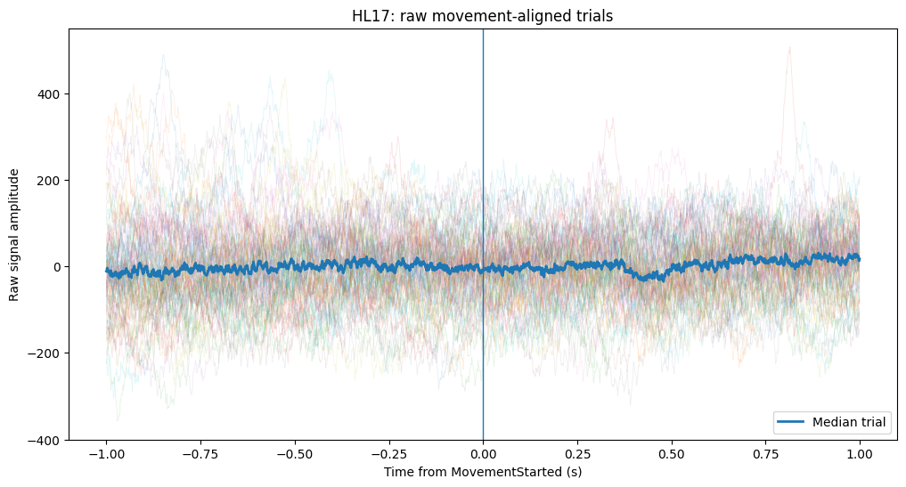

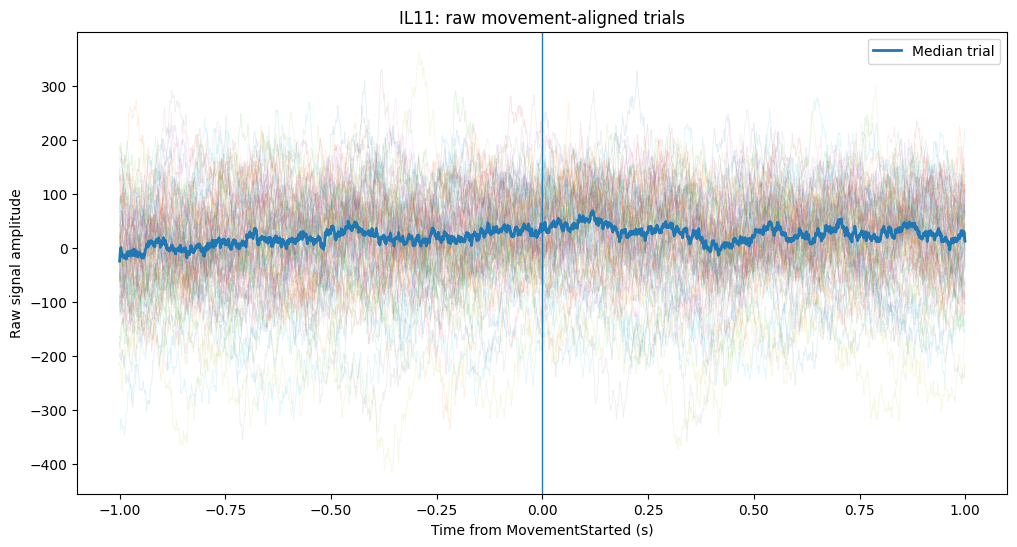

```python
RAW_WINDOW_S = (-1.0, 1.0)

raw_offsets = np.arange(
    int(round(RAW_WINDOW_S[0] * fs)),
    int(round(RAW_WINDOW_S[1] * fs)),
)

raw_times = raw_offsets / fs


def extract_raw_event_trials(
    signal_index,
):
    rows = []
    kept = []

    for trial_i, row in neural_trials.iterrows():
        onset = int(
            row["movement_onset_sample"]
        )

        indices = (
            onset
            + raw_offsets
        )

        if (
            indices[0] < 0
            or indices[-1] >= n_samples
        ):
            continue

        rows.append(
            signal[
                indices,
                signal_index,
            ].astype(np.float64)
        )

        kept.append(
            trial_i
        )

    return (
        np.vstack(rows),
        np.asarray(kept),
    )


def plot_raw_trial_overlay(
    channel_name,
    signal_index,
):
    raw_trials, kept = (
        extract_raw_event_trials(
            signal_index
        )
    )

    fig, ax = plt.subplots(
        figsize=(12, 6)
    )

    for trace in raw_trials:
        ax.plot(
            raw_times,
            trace,
            alpha=0.12,
            linewidth=0.6,
        )

    median_trace = np.nanmedian(
        raw_trials,
        axis=0,
    )

    ax.plot(
        raw_times,
        median_trace,
        linewidth=2,
        label="Median trial",
    )

    ax.axvline(
        0,
        linewidth=1,
    )

    ax.set_xlabel(
        "Time from MovementStarted (s)"
    )

    ax.set_ylabel(
        "Raw signal amplitude"
    )

    ax.set_title(
        f"{channel_name}: raw movement-aligned trials"
    )

    ax.legend()
    plt.show()

    return raw_trials, kept


hl17_raw_trials, hl17_raw_kept = (
    plot_raw_trial_overlay(
        "HL17",
        HL17_SIGNAL_INDEX,
    )
)

il11_raw_trials, il11_raw_kept = (
    plot_raw_trial_overlay(
        "IL11",
        IL11_SIGNAL_INDEX,
    )
)
```

## B1. Raw traces separated by HL17 context

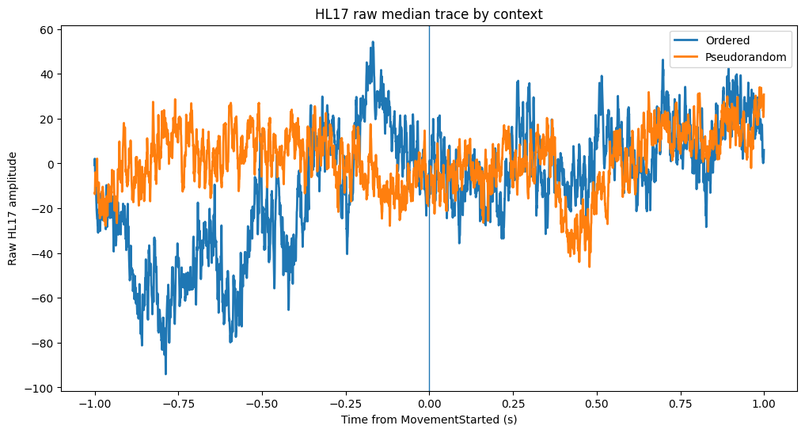

```python
hl17_context = neural_trials.loc[
    hl17_raw_kept,
    "context",
].to_numpy()

fig, ax = plt.subplots(
    figsize=(12, 6)
)

for context_name in [
    "Ordered",
    "Pseudorandom",
]:
    mask = (
        hl17_context
        == context_name
    )

    if mask.sum() == 0:
        continue

    median_trace = np.nanmedian(
        hl17_raw_trials[mask],
        axis=0,
    )

    ax.plot(
        raw_times,
        median_trace,
        linewidth=2,
        label=context_name,
    )

ax.axvline(
    0,
    linewidth=1,
)

ax.set_xlabel(
    "Time from MovementStarted (s)"
)

ax.set_ylabel(
    "Raw HL17 amplitude"
)

ax.set_title(
    "HL17 raw median trace by context"
)

ax.legend()
plt.show()
```

## B2. Raw amplitude and line-noise metrics for HL17 and IL11

These plots ask whether the trials with the strongest HFB responses are also the trials with the largest raw amplitudes or strongest 120 Hz changes.

```
HL17: HFB vs Movement peak-to-peak: rho=0.164, p=0.1454
```

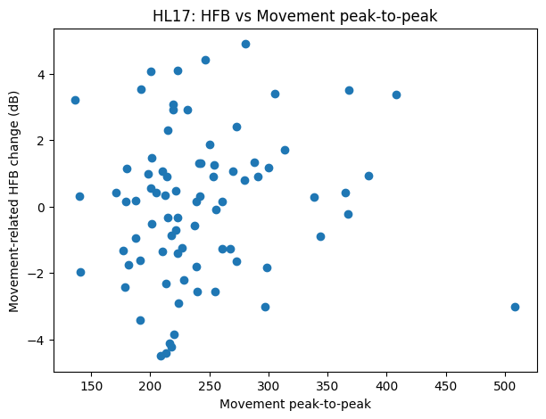

```
HL17: HFB vs Movement RMS: rho=0.268, p=0.01615
```

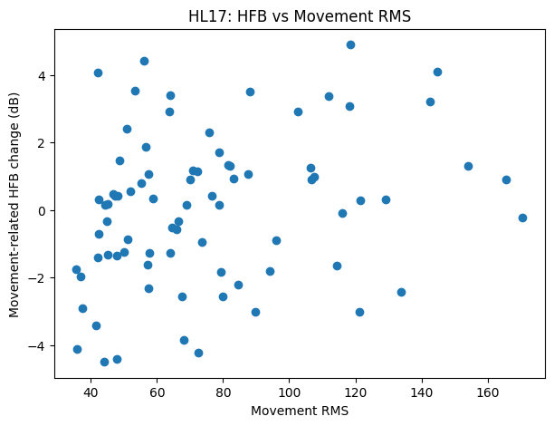

```
HL17: HFB vs 120 Hz change (dB): rho=0.135, p=0.2319
```

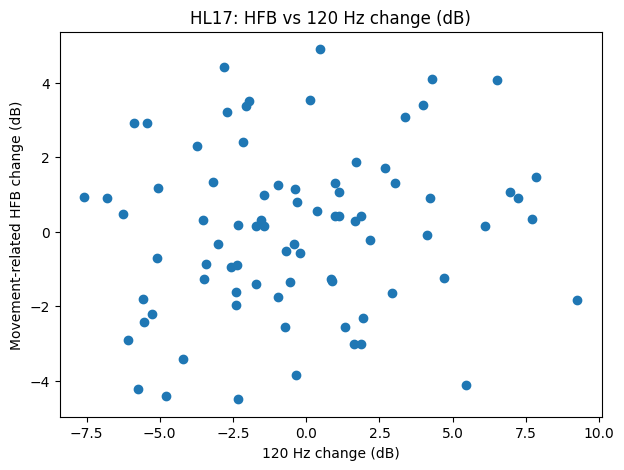

```
IL11: HFB vs Movement peak-to-peak: rho=0.036, p=0.7497
```

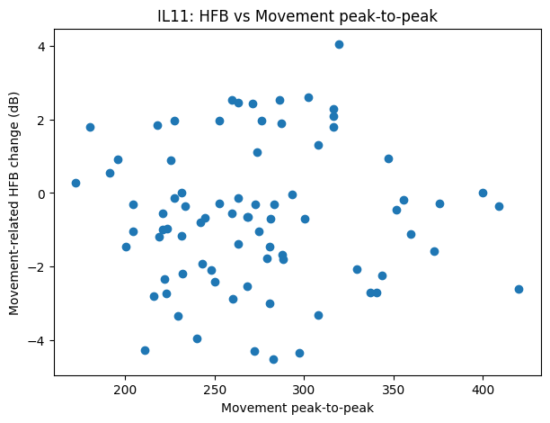

```
IL11: HFB vs Movement RMS: rho=0.031, p=0.7818
```

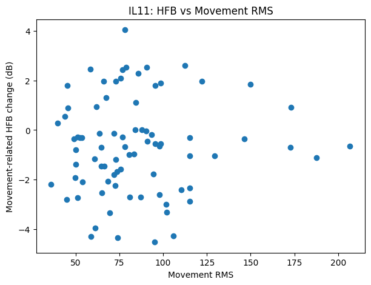

```
IL11: HFB vs 120 Hz change (dB): rho=0.251, p=0.02448
```

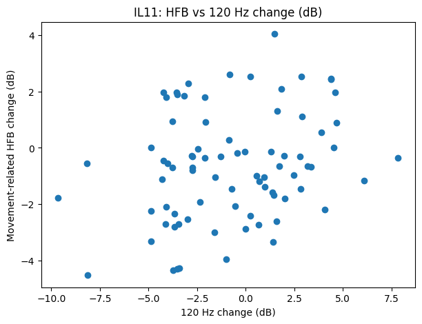

```python
def artifact_scatter_panel(
    channel_name,
    position,
):
    hfb_values = hfb[:, position]

    ptp_values = movement_ptp[
        :,
        position,
    ]

    rms_values = movement_rms[
        :,
        position,
    ]

    line120_values = line_changes[
        120.0
    ][
        :,
        position,
    ]

    metrics = {
        "Movement peak-to-peak": ptp_values,
        "Movement RMS": rms_values,
        "120 Hz change (dB)": line120_values,
    }

    for metric_name, values in metrics.items():
        valid = (
            np.isfinite(
                hfb_values
            )
            & np.isfinite(
                values
            )
        )

        stat = spearmanr(
            values[valid],
            hfb_values[valid],
        )

        print(
            f"{channel_name}: HFB vs {metric_name}: "
            f"rho={stat.statistic:.3f}, "
            f"p={stat.pvalue:.4g}"
        )

        fig, ax = plt.subplots(
            figsize=(7, 5)
        )

        ax.scatter(
            values[valid],
            hfb_values[valid],
        )

        ax.set_xlabel(
            metric_name
        )

        ax.set_ylabel(
            "Movement-related HFB change (dB)"
        )

        ax.set_title(
            f"{channel_name}: HFB vs {metric_name}"
        )

        plt.show()


artifact_scatter_panel(
    "HL17",
    HL17_POS,
)

artifact_scatter_panel(
    "IL11",
    IL11_POS,
)
```

## B3. Detect artifact-like trials with robust thresholds

A trial is flagged for a channel when either:

- movement peak-to-peak amplitude is more than 6 MAD above the channel median
- movement RMS is more than 6 MAD above the channel median
- absolute 120 Hz change is more than 6 MAD above the channel median

MAD means median absolute deviation.

This is not a universal artifact definition. It is a transparent sensitivity analysis that lets us ask whether the findings survive after obviously extreme trials are removed.

```python
def robust_outlier_mask(
    values,
    threshold=6.0,
    absolute=False,
):
    values = np.asarray(
        values,
        dtype=float,
    )

    if absolute:
        values = np.abs(
            values
        )

    median = np.nanmedian(
        values
    )

    mad = np.nanmedian(
        np.abs(
            values - median
        )
    )

    if (
        not np.isfinite(mad)
        or mad == 0
    ):
        return np.zeros(
            len(values),
            dtype=bool,
        )

    robust_z = (
        0.6745
        * (values - median)
        / mad
    )

    return robust_z > threshold


def channel_artifact_mask(
    position,
):
    ptp_flag = robust_outlier_mask(
        movement_ptp[
            :,
            position,
        ]
    )

    rms_flag = robust_outlier_mask(
        movement_rms[
            :,
            position,
        ]
    )

    line_flag = robust_outlier_mask(
        line_changes[
            120.0
        ][
            :,
            position,
        ],
        absolute=True,
    )

    return (
        ptp_flag
        | rms_flag
        | line_flag
    )


hl17_artifact = channel_artifact_mask(
    HL17_POS
)

il11_artifact = channel_artifact_mask(
    IL11_POS
)

print(
    f"HL17 flagged trials: "
    f"{hl17_artifact.sum()} / {len(hl17_artifact)}"
)

print(
    f"IL11 flagged trials: "
    f"{il11_artifact.sum()} / {len(il11_artifact)}"
)
```

```
HL17 flagged trials: 1 / 80
IL11 flagged trials: 0 / 80
```

# Part C: Spectral checks for HL17 and IL11

These plots compare baseline and movement PSDs directly.

The goal is to distinguish a broad HFB change from a narrow electrical-noise peak or unusual spectral artifact.

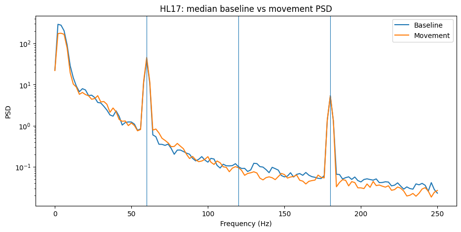

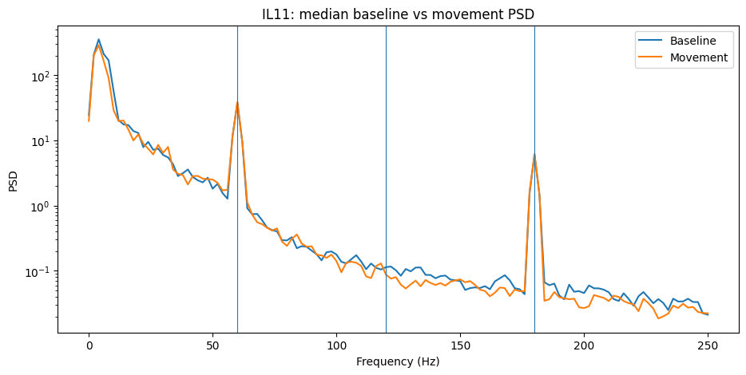

```python
def mean_psd_for_channel(
    signal_index,
):
    baseline_psds = []
    movement_psds = []
    frequencies = None

    for _, row in neural_trials.iterrows():
        onset = int(
            row["movement_onset_sample"]
        )

        b0 = onset + int(
            round(
                BASELINE_WINDOW_S[0]
                * fs
            )
        )

        b1 = onset + int(
            round(
                BASELINE_WINDOW_S[1]
                * fs
            )
        )

        m0 = onset + int(
            round(
                MOVEMENT_WINDOW_S[0]
                * fs
            )
        )

        m1 = onset + int(
            round(
                MOVEMENT_WINDOW_S[1]
                * fs
            )
        )

        baseline = signal[
            b0:b1,
            signal_index,
        ].astype(np.float64)

        movement = signal[
            m0:m1,
            signal_index,
        ].astype(np.float64)

        f_b, p_b = welch(
            baseline,
            fs=fs,
            nperseg=min(
                len(baseline),
                int(round(fs * 0.5)),
            ),
            detrend="constant",
            scaling="density",
        )

        f_m, p_m = welch(
            movement,
            fs=fs,
            nperseg=min(
                len(movement),
                int(round(fs * 0.5)),
            ),
            detrend="constant",
            scaling="density",
        )

        baseline_psds.append(
            p_b
        )

        movement_psds.append(
            p_m
        )

        frequencies = f_b

    return (
        frequencies,
        np.vstack(
            baseline_psds
        ),
        np.vstack(
            movement_psds
        ),
    )


def plot_psd_check(
    channel_name,
    signal_index,
):
    frequencies, baseline_psds, movement_psds = (
        mean_psd_for_channel(
            signal_index
        )
    )

    baseline_median = np.nanmedian(
        baseline_psds,
        axis=0,
    )

    movement_median = np.nanmedian(
        movement_psds,
        axis=0,
    )

    mask = (
        frequencies <= 250
    )

    fig, ax = plt.subplots(
        figsize=(11, 5)
    )

    ax.semilogy(
        frequencies[mask],
        baseline_median[mask],
        label="Baseline",
    )

    ax.semilogy(
        frequencies[mask],
        movement_median[mask],
        label="Movement",
    )

    for line_frequency in LINE_FREQS:
        ax.axvline(
            line_frequency,
            linewidth=0.8,
        )

    ax.set_xlabel(
        "Frequency (Hz)"
    )

    ax.set_ylabel(
        "PSD"
    )

    ax.set_title(
        f"{channel_name}: median baseline vs movement PSD"
    )

    ax.legend()
    plt.show()


plot_psd_check(
    "HL17",
    HL17_SIGNAL_INDEX,
)

plot_psd_check(
    "IL11",
    IL11_SIGNAL_INDEX,
)
```

## C1. Time-frequency maps for both interesting channels

Each trial is baseline-normalized. The plots show the average spectral change around movement onset.

A narrow horizontal stripe at exactly 60/120/180 Hz would be more suspicious for line noise than a broad physiological-looking spectral change.

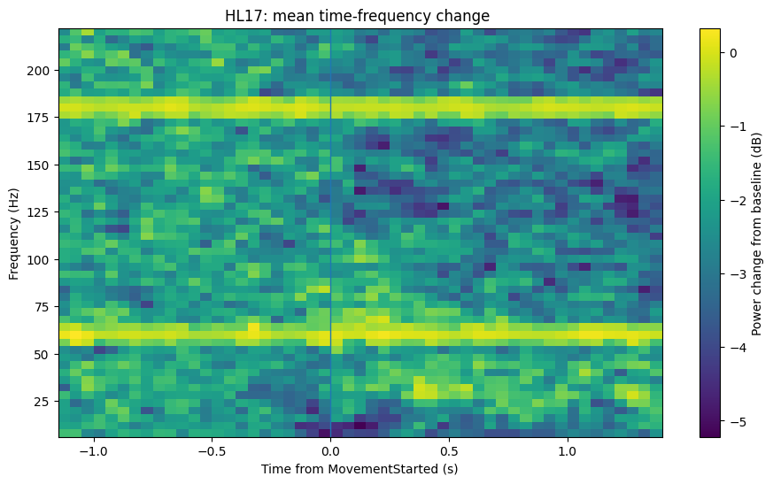

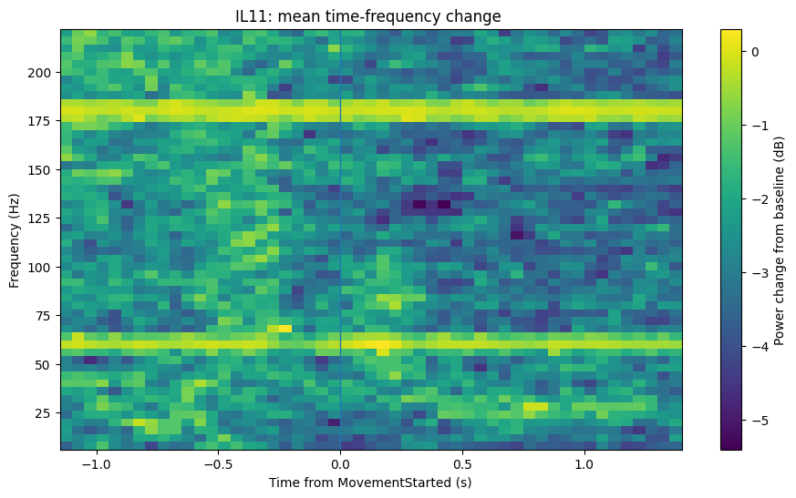

```python
TF_WINDOW_S = (-1.25, 1.50)
TF_MAX_HZ = 220.0


def average_time_frequency(
    signal_index,
    trial_mask=None,
):
    all_power_db = []
    frequencies = None
    times = None

    for trial_i, row in neural_trials.iterrows():
        if (
            trial_mask is not None
            and not trial_mask[trial_i]
        ):
            continue

        onset = int(
            row["movement_onset_sample"]
        )

        start = onset + int(
            round(
                TF_WINDOW_S[0]
                * fs
            )
        )

        stop = onset + int(
            round(
                TF_WINDOW_S[1]
                * fs
            )
        )

        if (
            start < 0
            or stop > n_samples
        ):
            continue

        x = signal[
            start:stop,
            signal_index,
        ].astype(np.float64)

        x = (
            x
            - np.nanmean(x)
        )

        x = np.nan_to_num(
            x
        )

        f_tf, t_tf, z_tf = stft(
            x,
            fs=fs,
            nperseg=int(
                round(
                    0.25 * fs
                )
            ),
            noverlap=int(
                round(
                    0.20 * fs
                )
            ),
            boundary=None,
            padded=False,
        )

        t_tf = (
            t_tf
            + TF_WINDOW_S[0]
        )

        power = (
            np.abs(z_tf) ** 2
        )

        frequency_mask = (
            (f_tf >= 5)
            & (f_tf <= TF_MAX_HZ)
        )

        f_tf = f_tf[
            frequency_mask
        ]

        power = power[
            frequency_mask
        ]

        baseline_mask = (
            (t_tf >= BASELINE_WINDOW_S[0])
            & (t_tf <= BASELINE_WINDOW_S[1])
        )

        baseline_spectrum = (
            np.nanmean(
                power[
                    :,
                    baseline_mask,
                ],
                axis=1,
                keepdims=True,
            )
        )

        power_db = (
            10
            * np.log10(
                (
                    power
                    + np.finfo(float).tiny
                )
                /
                (
                    baseline_spectrum
                    + np.finfo(float).tiny
                )
            )
        )

        all_power_db.append(
            power_db
        )

        frequencies = f_tf
        times = t_tf

    return (
        frequencies,
        times,
        np.nanmean(
            np.stack(
                all_power_db
            ),
            axis=0,
        ),
    )


def plot_time_frequency(
    channel_name,
    signal_index,
    trial_mask=None,
    title_suffix="",
):
    frequencies, times, mean_power_db = (
        average_time_frequency(
            signal_index,
            trial_mask=trial_mask,
        )
    )

    fig, ax = plt.subplots(
        figsize=(11, 6)
    )

    mesh = ax.pcolormesh(
        times,
        frequencies,
        mean_power_db,
        shading="auto",
    )

    ax.axvline(
        0,
        linewidth=1,
    )

    ax.set_xlabel(
        "Time from MovementStarted (s)"
    )

    ax.set_ylabel(
        "Frequency (Hz)"
    )

    ax.set_title(
        f"{channel_name}: mean time-frequency change {title_suffix}"
    )

    fig.colorbar(
        mesh,
        ax=ax,
        label="Power change from baseline (dB)",
    )

    plt.show()


plot_time_frequency(
    "HL17",
    HL17_SIGNAL_INDEX,
)

plot_time_frequency(
    "IL11",
    IL11_SIGNAL_INDEX,
)
```

# Part D: HL17 context effect under stricter controls

A major limitation of the Ordered vs Pseudorandom result is that the experiment is temporally structured: the Ordered trials occur earlier and the Pseudorandom trials later.

That means `context` is partially confounded with recording time.

This section asks whether HL17 still shows a context effect after accounting for:

- linear trial drift
- quadratic trial drift
- pupil size
- reaction time
- movement time
- joystick path
- global HFB fluctuations
- artifact-like trials

```python
hl17_hfb = hfb[
    :,
    HL17_POS,
]

ordered_mask = (
    neural_trials["context"]
    == "Ordered"
).to_numpy()

pseudo_mask = (
    neural_trials["context"]
    == "Pseudorandom"
).to_numpy()

print(
    f"Ordered mean: "
    f"{np.nanmean(hl17_hfb[ordered_mask]):.3f} dB"
)

print(
    f"Pseudorandom mean: "
    f"{np.nanmean(hl17_hfb[pseudo_mask]):.3f} dB"
)

print(
    f"Difference: "
    f"{np.nanmean(hl17_hfb[pseudo_mask]) - np.nanmean(hl17_hfb[ordered_mask]):.3f} dB"
)
```

```
Ordered mean: -1.511 dB
Pseudorandom mean: 0.554 dB
Difference: 2.065 dB
```

## D1. Plot HL17 across recording time

If the apparent context effect is actually a slow drift, the trial-by-trial plot should make that visible.

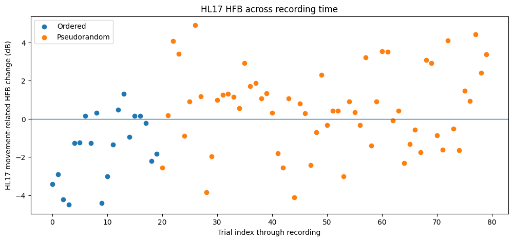

```python
fig, ax = plt.subplots(
    figsize=(12, 5)
)

for context_name in [
    "Ordered",
    "Pseudorandom",
]:
    mask = (
        neural_trials["context"]
        == context_name
    ).to_numpy()

    ax.scatter(
        neural_trials.loc[
            mask,
            "analysis_trial_index",
        ],
        hl17_hfb[mask],
        label=context_name,
    )

ax.axhline(
    0,
    linewidth=1,
)

ax.set_xlabel(
    "Trial index through recording"
)

ax.set_ylabel(
    "HL17 movement-related HFB change (dB)"
)

ax.set_title(
    "HL17 HFB across recording time"
)

ax.legend()
plt.show()
```

## D2. Decode and clean pupil size

The previous analysis showed a strong pupil difference between contexts.

This cell uses left/right eye validity when possible. Because the file's validity states use values 0 and 4, the notebook does not assume the meaning silently. It prints the distributions and then uses the nonzero code as the valid-eye mask for this sensitivity analysis.

If your eye-tracker documentation defines the codes differently, change `VALIDITY_IS_NONZERO`.

```python
VALIDITY_IS_NONZERO = True

left_pupil_name = (
    "EyetrackerLeftPupilSize"
)

right_pupil_name = (
    "EyetrackerRightPupilSize"
)

left_valid_name = (
    "EyetrackerLeftEyeValidity"
)

right_valid_name = (
    "EyetrackerRightEyeValidity"
)

if (
    left_pupil_name in states
    and right_pupil_name in states
):
    left_pupil = states[
        left_pupil_name
    ].astype(float)

    right_pupil = states[
        right_pupil_name
    ].astype(float)

    if (
        left_valid_name in states
        and right_valid_name in states
    ):
        print(
            "Left validity values:",
            np.unique(
                states[
                    left_valid_name
                ]
            ),
        )

        print(
            "Right validity values:",
            np.unique(
                states[
                    right_valid_name
                ]
            ),
        )

        if VALIDITY_IS_NONZERO:
            left_valid = (
                states[
                    left_valid_name
                ]
                != 0
            )

            right_valid = (
                states[
                    right_valid_name
                ]
                != 0
            )
        else:
            left_valid = (
                states[
                    left_valid_name
                ]
                == 0
            )

            right_valid = (
                states[
                    right_valid_name
                ]
                == 0
            )
    else:
        left_valid = np.ones(
            n_samples,
            dtype=bool,
        )

        right_valid = np.ones(
            n_samples,
            dtype=bool,
        )

    left_clean = np.where(
        left_valid
        & (left_pupil > 0),
        left_pupil,
        np.nan,
    )

    right_clean = np.where(
        right_valid
        & (right_pupil > 0),
        right_pupil,
        np.nan,
    )

    pupil_clean = np.nanmean(
        np.vstack([
            left_clean,
            right_clean,
        ]),
        axis=0,
    )
else:
    pupil_clean = np.full(
        n_samples,
        np.nan,
    )

trial_pupil = []

for _, row in neural_trials.iterrows():
    start = int(
        row["trial_start_sample"]
    )

    onset = int(
        row["movement_onset_sample"]
    )

    values = pupil_clean[
        start:onset + 1
    ]

    trial_pupil.append(
        np.nanmedian(
            values
        )
    )

neural_trials[
    "clean_pupil_pre_movement"
] = trial_pupil

display(
    neural_trials[
        [
            "trial",
            "context",
            "clean_pupil_pre_movement",
        ]
    ].head(20)
)
```

```
Left validity values: [0 4]
Right validity values: [0 4]
```

|  | trial | context | clean_pupil_pre_movement |
| --- | --- | --- | --- |
| 0 | 1 | Ordered | 230.0 |
| 1 | 2 | Ordered | 237.0 |
| 2 | 3 | Ordered | 268.0 |
| 3 | 4 | Ordered | NaN |
| 4 | 5 | Ordered | NaN |
| 5 | 6 | Ordered | 221.5 |
| 6 | 7 | Ordered | 228.0 |
| 7 | 8 | Ordered | NaN |
| 8 | 9 | Ordered | NaN |
| 9 | 10 | Ordered | NaN |
| 10 | 11 | Ordered | 233.0 |
| 11 | 12 | Ordered | 228.0 |
| 12 | 13 | Ordered | 231.0 |
| 13 | 14 | Ordered | 228.5 |
| 14 | 15 | Ordered | NaN |
| 15 | 16 | Ordered | 195.0 |
| 16 | 17 | Ordered | NaN |
| 17 | 18 | Ordered | 234.5 |
| 18 | 19 | Ordered | 230.0 |
| 19 | 20 | Ordered | NaN |

## D3. Ordinary least-squares helper

This returns coefficients, standard errors, t statistics, and p-values without requiring an additional statistics package.

```python
def ols_table(
    y,
    predictors,
):
    """
    predictors:
        dict of column_name -> 1D array
    """
    y = np.asarray(
        y,
        dtype=float,
    )

    predictor_names = list(
        predictors.keys()
    )

    predictor_arrays = [
        np.asarray(
            predictors[name],
            dtype=float,
        )
        for name in predictor_names
    ]

    valid = np.isfinite(
        y
    )

    for values in predictor_arrays:
        valid &= np.isfinite(
            values
        )

    y_valid = y[
        valid
    ]

    X = np.column_stack(
        [
            np.ones(
                valid.sum()
            )
        ]
        + [
            values[
                valid
            ]
            for values in predictor_arrays
        ]
    )

    names = [
        "Intercept"
    ] + predictor_names

    if (
        X.shape[0]
        <= X.shape[1]
    ):
        raise ValueError(
            "Not enough valid observations for regression."
        )

    beta_hat, _, _, _ = (
        np.linalg.lstsq(
            X,
            y_valid,
            rcond=None,
        )
    )

    residuals = (
        y_valid
        - X @ beta_hat
    )

    dof = (
        X.shape[0]
        - X.shape[1]
    )

    sigma2 = (
        np.sum(
            residuals ** 2
        )
        / dof
    )

    xtx_inv = np.linalg.pinv(
        X.T @ X
    )

    standard_errors = np.sqrt(
        np.diag(
            sigma2 * xtx_inv
        )
    )

    t_values = (
        beta_hat
        / standard_errors
    )

    p_values = (
        2
        * t_distribution.sf(
            np.abs(
                t_values
            ),
            dof,
        )
    )

    ss_total = np.sum(
        (
            y_valid
            - np.mean(
                y_valid
            )
        ) ** 2
    )

    ss_res = np.sum(
        residuals ** 2
    )

    r2 = (
        1
        - ss_res / ss_total
        if ss_total > 0
        else np.nan
    )

    table = pd.DataFrame({
        "term": names,
        "coefficient": beta_hat,
        "std_error": standard_errors,
        "t": t_values,
        "p": p_values,
    })

    return (
        table,
        r2,
        valid,
        residuals,
    )
```

## D4. HL17 context effect after global-HFB and drift controls

```python
context_binary = (
    neural_trials["context"]
    == "Pseudorandom"
).astype(float).to_numpy()

trial_index = neural_trials[
    "analysis_trial_index"
].astype(float).to_numpy()

trial_index_z = (
    trial_index
    - np.mean(trial_index)
) / np.std(trial_index)

global_hfb_z = (
    global_hfb
    - np.nanmean(global_hfb)
) / np.nanstd(global_hfb)

predictors = {
    "Pseudorandom_context": context_binary,
    "trial_index": trial_index_z,
    "trial_index_squared": trial_index_z ** 2,
    "global_HFB": global_hfb_z,
}

optional_columns = {
    "pupil": "clean_pupil_pre_movement",
    "reaction_time": "ReactionTimeMs",
    "movement_time": "MovementTimeMs",
    "joystick_path": "joystick_path",
}

for predictor_name, column_name in optional_columns.items():
    if column_name not in neural_trials.columns:
        continue

    values = neural_trials[
        column_name
    ].astype(float).to_numpy()

    if column_name in {
        "ReactionTimeMs",
        "MovementTimeMs",
    }:
        values[
            values <= 0
        ] = np.nan

    if np.isfinite(values).sum() >= 10:
        mean = np.nanmean(
            values
        )

        std = np.nanstd(
            values
        )

        if std > 0:
            predictors[
                predictor_name
            ] = (
                values - mean
            ) / std

hl17_model, hl17_r2, _, _ = (
    ols_table(
        hl17_hfb,
        predictors,
    )
)

print(
    f"HL17 multivariable model R^2 = "
    f"{hl17_r2:.3f}"
)

display(
    hl17_model
)
```

```
HL17 multivariable model R^2 = 0.274
```

|  | term | coefficient | std_error | t | p |
| --- | --- | --- | --- | --- | --- |
| 0 | Intercept | -0.776474 | 1.446143 | -0.536927 | 0.593608 |
| 1 | Pseudorandom_context | 0.625956 | 1.447877 | 0.432327 | 0.667292 |
| 2 | trial_index | 0.799915 | 0.550116 | 1.454085 | 0.151932 |
| 3 | trial_index_squared | 0.168206 | 0.424354 | 0.396382 | 0.693445 |
| 4 | global_HFB | 0.524268 | 0.266942 | 1.963978 | 0.054889 |
| 5 | pupil | -0.082169 | 0.280829 | -0.292595 | 0.770996 |
| 6 | reaction_time | -0.327354 | 0.250180 | -1.308477 | 0.196466 |
| 7 | movement_time | 0.054076 | 0.606150 | 0.089212 | 0.929256 |
| 8 | joystick_path | 0.295829 | 0.620040 | 0.477113 | 0.635281 |

## D5. HL17 context effect after removing artifact-like trials

This reruns the simple context comparison after excluding HL17 trials flagged by the robust artifact screen.

```python
hl17_clean_mask = (
    ~hl17_artifact
    & np.isfinite(
        hl17_hfb
    )
)

ordered_clean = (
    hl17_clean_mask
    & ordered_mask
)

pseudo_clean = (
    hl17_clean_mask
    & pseudo_mask
)

test_clean = ttest_ind(
    hl17_hfb[
        pseudo_clean
    ],
    hl17_hfb[
        ordered_clean
    ],
    equal_var=False,
    nan_policy="omit",
)

print(
    f"Clean Ordered trials: "
    f"{ordered_clean.sum()}"
)

print(
    f"Clean Pseudorandom trials: "
    f"{pseudo_clean.sum()}"
)

print(
    f"Clean Ordered mean: "
    f"{np.nanmean(hl17_hfb[ordered_clean]):.3f} dB"
)

print(
    f"Clean Pseudorandom mean: "
    f"{np.nanmean(hl17_hfb[pseudo_clean]):.3f} dB"
)

print(
    f"Clean difference: "
    f"{np.nanmean(hl17_hfb[pseudo_clean]) - np.nanmean(hl17_hfb[ordered_clean]):.3f} dB"
)

print(
    f"Welch p after artifact exclusion: "
    f"{test_clean.pvalue:.6g}"
)
```

```
Clean Ordered trials: 20
Clean Pseudorandom trials: 59
Clean Ordered mean: -1.511 dB
Clean Pseudorandom mean: 0.615 dB
Clean difference: 2.126 dB
Welch p after artifact exclusion: 7.25223e-05
```

# Part E: Local spatial specificity around HL17

A local neural effect should ideally show some spatial structure across nearby contacts.

This section compares all contacts on the HL shaft and the adjacent bipolar pairs around HL17.

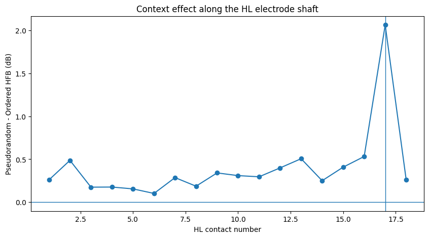

|  | channel_name | contact | context_difference_db | p |
| --- | --- | --- | --- | --- |
| 0 | HL1 | 1 | 0.259329 | 0.576236 |
| 1 | HL2 | 2 | 0.487011 | 0.287759 |
| 2 | HL3 | 3 | 0.174788 | 0.723314 |
| 3 | HL4 | 4 | 0.176145 | 0.718511 |
| 4 | HL5 | 5 | 0.154716 | 0.743845 |
| 5 | HL6 | 6 | 0.101593 | 0.826401 |
| 6 | HL7 | 7 | 0.286197 | 0.521231 |
| 7 | HL8 | 8 | 0.186076 | 0.645111 |
| 8 | HL9 | 9 | 0.340805 | 0.355307 |
| 9 | HL10 | 10 | 0.309309 | 0.508983 |
| 10 | HL11 | 11 | 0.295813 | 0.515994 |
| 11 | HL12 | 12 | 0.399524 | 0.355576 |
| 12 | HL13 | 13 | 0.506350 | 0.209052 |
| 13 | HL14 | 14 | 0.249958 | 0.525800 |
| 14 | HL15 | 15 | 0.407889 | 0.289957 |
| 15 | HL16 | 16 | 0.532084 | 0.185684 |
| 16 | HL17 | 17 | 2.065318 | 0.000109 |
| 17 | HL18 | 18 | 0.259024 | 0.596282 |

```python
hl_contacts = (
    intracranial_channels.loc[
        intracranial_channels[
            "electrode"
        ] == "HL"
    ]
    .sort_values(
        "contact"
    )
    .reset_index(drop=True)
)

hl_context_rows = []

for _, contact_row in hl_contacts.iterrows():
    pos = channel_position(
        contact_row[
            "channel_name"
        ]
    )

    values = hfb[
        :,
        pos,
    ]

    difference = (
        np.nanmean(
            values[
                pseudo_mask
            ]
        )
        - np.nanmean(
            values[
                ordered_mask
            ]
        )
    )

    test = ttest_ind(
        values[
            pseudo_mask
        ],
        values[
            ordered_mask
        ],
        equal_var=False,
        nan_policy="omit",
    )

    hl_context_rows.append({
        "channel_name": contact_row[
            "channel_name"
        ],
        "contact": contact_row[
            "contact"
        ],
        "context_difference_db": difference,
        "p": test.pvalue,
    })

hl_context_table = pd.DataFrame(
    hl_context_rows
)

fig, ax = plt.subplots(
    figsize=(10, 5)
)

ax.plot(
    hl_context_table[
        "contact"
    ],
    hl_context_table[
        "context_difference_db"
    ],
    marker="o",
)

ax.axhline(
    0,
    linewidth=1,
)

ax.axvline(
    17,
    linewidth=1,
)

ax.set_xlabel(
    "HL contact number"
)

ax.set_ylabel(
    "Pseudorandom - Ordered HFB (dB)"
)

ax.set_title(
    "Context effect along the HL electrode shaft"
)

plt.show()

display(
    hl_context_table
)
```

## E1. HL17 adjacent bipolar pairs

Two local bipolar signals are evaluated:

- HL17 - HL16
- HL18 - HL17

If a context effect survives in one or both, it is less likely to be explained purely by a distant common reference.

```python
def bipolar_signal(
    positive_name,
    negative_name,
):
    positive_index = signal_index_for(
        positive_name
    )

    negative_index = signal_index_for(
        negative_name
    )

    return (
        signal[
            :,
            positive_index,
        ].astype(np.float64)
        - signal[
            :,
            negative_index,
        ].astype(np.float64)
    )


def trial_hfb_for_1d_signal(
    one_d_signal,
):
    responses = []

    for _, row in neural_trials.iterrows():
        onset = int(
            row[
                "movement_onset_sample"
            ]
        )

        b0 = onset + int(
            round(
                BASELINE_WINDOW_S[0]
                * fs
            )
        )

        b1 = onset + int(
            round(
                BASELINE_WINDOW_S[1]
                * fs
            )
        )

        m0 = onset + int(
            round(
                MOVEMENT_WINDOW_S[0]
                * fs
            )
        )

        m1 = onset + int(
            round(
                MOVEMENT_WINDOW_S[1]
                * fs
            )
        )

        baseline = one_d_signal[
            b0:b1
        ]

        movement = one_d_signal[
            m0:m1
        ]

        f_b, p_b = welch(
            baseline,
            fs=fs,
            nperseg=min(
                len(baseline),
                int(round(fs * 0.25)),
            ),
            noverlap=min(
                len(baseline),
                int(round(fs * 0.25)),
            ) // 2,
            detrend="constant",
            scaling="density",
        )

        f_m, p_m = welch(
            movement,
            fs=fs,
            nperseg=min(
                len(movement),
                int(round(fs * 0.25)),
            ),
            noverlap=min(
                len(movement),
                int(round(fs * 0.25)),
            ) // 2,
            detrend="constant",
            scaling="density",
        )

        base_power = integrate_band(
            f_b,
            p_b,
            70.0,
            150.0,
            remove_line_noise=True,
        )

        move_power = integrate_band(
            f_m,
            p_m,
            70.0,
            150.0,
            remove_line_noise=True,
        )

        responses.append(
            10
            * np.log10(
                (
                    move_power
                    + np.finfo(float).tiny
                )
                /
                (
                    base_power
                    + np.finfo(float).tiny
                )
            )
        )

    return np.asarray(
        responses
    )


hl17_minus_hl16 = (
    trial_hfb_for_1d_signal(
        bipolar_signal(
            "HL17",
            "HL16",
        )
    )
)

hl18_minus_hl17 = (
    trial_hfb_for_1d_signal(
        bipolar_signal(
            "HL18",
            "HL17",
        )
    )
)

for pair_name, values in {
    "HL17-HL16": hl17_minus_hl16,
    "HL18-HL17": hl18_minus_hl17,
}.items():
    difference = (
        np.nanmean(
            values[
                pseudo_mask
            ]
        )
        - np.nanmean(
            values[
                ordered_mask
            ]
        )
    )

    test = ttest_ind(
        values[
            pseudo_mask
        ],
        values[
            ordered_mask
        ],
        equal_var=False,
        nan_policy="omit",
    )

    print(
        f"{pair_name}: "
        f"Pseudorandom - Ordered = "
        f"{difference:.3f} dB, "
        f"p={test.pvalue:.6g}"
    )
```

```
HL17-HL16: Pseudorandom - Ordered = 2.456 dB, p=0.000650047
HL18-HL17: Pseudorandom - Ordered = 2.718 dB, p=0.00200037
```

# Part F: Refine IL11 target-direction tuning

The target coordinates form a circle, but using the median X and Y as the center can bias the estimated angle when target sampling is uneven.

This notebook instead fits the circle center directly from the target coordinates.

```
Fitted center: X=510.05, Y=518.90
Fitted radius: 293.65
```

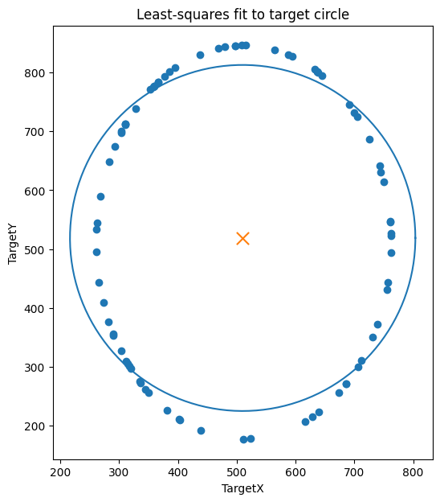

```python
target_x = neural_trials[
    "TargetX_move"
].astype(float).to_numpy()

target_y = neural_trials[
    "TargetY_move"
].astype(float).to_numpy()


def fit_circle_center(
    x,
    y,
):
    """
    Algebraic least-squares circle fit:
        x^2 + y^2 + D*x + E*y + F = 0
    """
    x = np.asarray(
        x,
        dtype=float,
    )

    y = np.asarray(
        y,
        dtype=float,
    )

    valid = (
        np.isfinite(x)
        & np.isfinite(y)
    )

    x = x[
        valid
    ]

    y = y[
        valid
    ]

    A = np.column_stack([
        x,
        y,
        np.ones(
            len(x)
        ),
    ])

    b = -(
        x ** 2
        + y ** 2
    )

    D, E, F = np.linalg.lstsq(
        A,
        b,
        rcond=None,
    )[0]

    center_x = -D / 2
    center_y = -E / 2

    radius = np.sqrt(
        max(
            0,
            center_x ** 2
            + center_y ** 2
            - F,
        )
    )

    return (
        center_x,
        center_y,
        radius,
    )


circle_x, circle_y, circle_radius = (
    fit_circle_center(
        target_x,
        target_y,
    )
)

dx = (
    target_x
    - circle_x
)

dy = (
    target_y
    - circle_y
)

derived_angle = (
    np.degrees(
        np.arctan2(
            -dy,
            dx,
        )
    )
    % 360
)

neural_trials[
    "target_direction_circle_deg"
] = derived_angle

print(
    f"Fitted center: "
    f"X={circle_x:.2f}, "
    f"Y={circle_y:.2f}"
)

print(
    f"Fitted radius: "
    f"{circle_radius:.2f}"
)

fig, ax = plt.subplots(
    figsize=(7, 7)
)

ax.scatter(
    target_x,
    target_y,
)

ax.scatter(
    [circle_x],
    [circle_y],
    marker="x",
    s=120,
)

circle_theta = np.linspace(
    0,
    2 * np.pi,
    300,
)

ax.plot(
    circle_x
    + circle_radius
    * np.cos(
        circle_theta
    ),
    circle_y
    + circle_radius
    * np.sin(
        circle_theta
    ),
)

ax.set_aspect(
    "equal",
    adjustable="box",
)

ax.set_xlabel(
    "TargetX"
)

ax.set_ylabel(
    "TargetY"
)

ax.set_title(
    "Least-squares fit to target circle"
)

plt.show()
```

## F1. Compare recorded TargetAngle with X/Y-derived direction

`TargetAngle` appears to be stored in tenths of a degree. This check determines whether it is consistent with the geometry after allowing for coordinate-system orientation and offset.

```
Best orientation: reversed
Best circular offset: 359.95 degrees
Median absolute circular error: 6.53 degrees
```

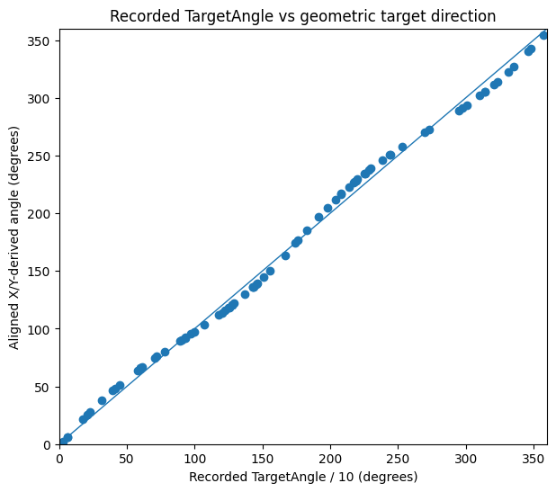

```python
if "TargetAngle" in neural_trials.columns:
    recorded_angle = (
        neural_trials[
            "TargetAngle"
        ].astype(float).to_numpy()
        / 10.0
    )

    # Compare both possible orientation conventions.
    candidate_1 = (
        derived_angle
    )

    candidate_2 = (
        (-derived_angle)
        % 360
    )

    def circular_offset_error(
        source,
        target,
    ):
        delta = np.deg2rad(
            (
                target
                - source
            )
            % 360
        )

        mean_vector = np.nanmean(
            np.exp(
                1j * delta
            )
        )

        offset = (
            np.degrees(
                np.angle(
                    mean_vector
                )
            )
            % 360
        )

        aligned = (
            source
            + offset
        ) % 360

        error = np.abs(
            (
                aligned
                - target
                + 180
            )
            % 360
            - 180
        )

        return (
            offset,
            np.nanmedian(
                error
            ),
            aligned,
        )

    result_1 = circular_offset_error(
        candidate_1,
        recorded_angle,
    )

    result_2 = circular_offset_error(
        candidate_2,
        recorded_angle,
    )

    if result_1[1] <= result_2[1]:
        chosen_orientation = (
            "derived"
        )
        target_angle_aligned = (
            result_1[2]
        )
        target_angle_offset = (
            result_1[0]
        )
        median_angle_error = (
            result_1[1]
        )
    else:
        chosen_orientation = (
            "reversed"
        )
        target_angle_aligned = (
            result_2[2]
        )
        target_angle_offset = (
            result_2[0]
        )
        median_angle_error = (
            result_2[1]
        )

    print(
        f"Best orientation: "
        f"{chosen_orientation}"
    )

    print(
        f"Best circular offset: "
        f"{target_angle_offset:.2f} degrees"
    )

    print(
        f"Median absolute circular error: "
        f"{median_angle_error:.2f} degrees"
    )

    fig, ax = plt.subplots(
        figsize=(7, 6)
    )

    ax.scatter(
        recorded_angle,
        target_angle_aligned,
    )

    ax.plot(
        [0, 360],
        [0, 360],
        linewidth=1,
    )

    ax.set_xlim(
        0,
        360,
    )

    ax.set_ylim(
        0,
        360,
    )

    ax.set_xlabel(
        "Recorded TargetAngle / 10 (degrees)"
    )

    ax.set_ylabel(
        "Aligned X/Y-derived angle (degrees)"
    )

    ax.set_title(
        "Recorded TargetAngle vs geometric target direction"
    )

    plt.show()
```

## F2. Circular tuning helper

```python
def circular_direction_test(
    y,
    theta_deg,
    extra_predictors=None,
):
    y = np.asarray(
        y,
        dtype=float,
    )

    theta_deg = np.asarray(
        theta_deg,
        dtype=float,
    )

    theta = np.deg2rad(
        theta_deg
    )

    predictor_columns = [
        np.cos(theta),
        np.sin(theta),
    ]

    predictor_names = [
        "cos_theta",
        "sin_theta",
    ]

    if extra_predictors is not None:
        for name, values in extra_predictors.items():
            predictor_names.append(
                name
            )

            predictor_columns.append(
                np.asarray(
                    values,
                    dtype=float,
                )
            )

    valid = np.isfinite(
        y
    )

    for values in predictor_columns:
        valid &= np.isfinite(
            values
        )

    y_valid = y[
        valid
    ]

    predictor_columns = [
        values[
            valid
        ]
        for values in predictor_columns
    ]

    X_full = np.column_stack(
        [
            np.ones(
                len(y_valid)
            )
        ]
        + predictor_columns
    )

    beta_full, _, _, _ = (
        np.linalg.lstsq(
            X_full,
            y_valid,
            rcond=None,
        )
    )

    predicted_full = (
        X_full @ beta_full
    )

    ss_full = np.sum(
        (
            y_valid
            - predicted_full
        ) ** 2
    )

    if extra_predictors is None:
        X_reduced = np.ones(
            (
                len(y_valid),
                1,
            )
        )
    else:
        extra_arrays = [
            np.asarray(
                extra_predictors[name],
                dtype=float,
            )[
                valid
            ]
            for name in extra_predictors
        ]

        X_reduced = np.column_stack(
            [
                np.ones(
                    len(y_valid)
                )
            ]
            + extra_arrays
        )

    beta_reduced, _, _, _ = (
        np.linalg.lstsq(
            X_reduced,
            y_valid,
            rcond=None,
        )
    )

    predicted_reduced = (
        X_reduced
        @ beta_reduced
    )

    ss_reduced = np.sum(
        (
            y_valid
            - predicted_reduced
        ) ** 2
    )

    df_added = 2
    df_resid = (
        len(y_valid)
        - X_full.shape[1]
    )

    if (
        df_resid <= 0
        or ss_full <= 0
    ):
        return {
            "F": np.nan,
            "p": np.nan,
            "r2": np.nan,
            "preferred_direction_deg": np.nan,
        }

    F_value = (
        (
            ss_reduced
            - ss_full
        )
        / df_added
    ) / (
        ss_full
        / df_resid
    )

    p_value = f_distribution.sf(
        F_value,
        df_added,
        df_resid,
    )

    ss_total = np.sum(
        (
            y_valid
            - np.mean(
                y_valid
            )
        ) ** 2
    )

    r2 = (
        1
        - ss_full / ss_total
        if ss_total > 0
        else np.nan
    )

    preferred_direction = (
        np.degrees(
            np.arctan2(
                beta_full[2],
                beta_full[1],
            )
        )
        % 360
    )

    return {
        "F": F_value,
        "p": p_value,
        "r2": r2,
        "preferred_direction_deg": preferred_direction,
    }
```

## F3. IL11 direction tuning with increasingly strict controls

The same IL11 response is tested four ways:

1. raw HFB
2. after subtracting each trial's global median HFB
3. after excluding artifact-like IL11 trials
4. after both global-HFB removal and artifact exclusion

```python
il11_hfb = hfb[
    :,
    IL11_POS,
]

theta = neural_trials[
    "target_direction_circle_deg"
].to_numpy()

il11_global_corrected = (
    il11_hfb
    - global_hfb
)

il11_clean = (
    ~il11_artifact
)

direction_checks = []

for label, values, mask in [
    (
        "Raw IL11 HFB",
        il11_hfb,
        np.ones(
            len(il11_hfb),
            dtype=bool,
        ),
    ),
    (
        "Global-corrected IL11 HFB",
        il11_global_corrected,
        np.ones(
            len(il11_hfb),
            dtype=bool,
        ),
    ),
    (
        "Artifact-excluded IL11 HFB",
        il11_hfb,
        il11_clean,
    ),
    (
        "Global-corrected + artifact-excluded",
        il11_global_corrected,
        il11_clean,
    ),
]:
    result = circular_direction_test(
        values[
            mask
        ],
        theta[
            mask
        ],
    )

    direction_checks.append({
        "analysis": label,
        **result,
        "n_trials": int(
            mask.sum()
        ),
    })

direction_checks = pd.DataFrame(
    direction_checks
)

display(
    direction_checks
)
```

|  | analysis | F | p | r2 | preferred_direction_deg | n_trials |
| --- | --- | --- | --- | --- | --- | --- |
| 0 | Raw IL11 HFB | 9.980751 | 0.000140 | 0.205870 | 178.599441 | 80 |
| 1 | Global-corrected IL11 HFB | 9.362071 | 0.000229 | 0.195605 | 186.359377 | 80 |
| 2 | Artifact-excluded IL11 HFB | 9.980751 | 0.000140 | 0.205870 | 178.599441 | 80 |
| 3 | Global-corrected + artifact-excluded | 9.362071 | 0.000229 | 0.195605 | 186.359377 | 80 |

## F4. IL11 direction tuning after controlling for context and trial drift

This model tests the sine/cosine direction terms after accounting for:

- Ordered/Pseudorandom context
- linear trial drift
- quadratic trial drift
- global HFB

```python
extra_predictors = {
    "context": context_binary,
    "trial_index": trial_index_z,
    "trial_index_squared": trial_index_z ** 2,
    "global_HFB": global_hfb_z,
}

il11_controlled_direction = (
    circular_direction_test(
        il11_hfb,
        theta,
        extra_predictors=extra_predictors,
    )
)

display(
    pd.DataFrame([
        il11_controlled_direction
    ])
)
```

|  | F | p | r2 | preferred_direction_deg |
| --- | --- | --- | --- | --- |
| 0 | 11.160258 | 0.000059 | 0.342041 | 182.828898 |

## F5. Permutation test for IL11 direction tuning

The target angles are randomly shuffled across trials while the IL11 HFB values remain fixed.

This produces an empirical null distribution for the directional F statistic.

The number of permutations can be increased for a more precise estimate.

```
Observed F: 9.981
Parametric p: 0.0001399
Permutation p: 0.00059988
```

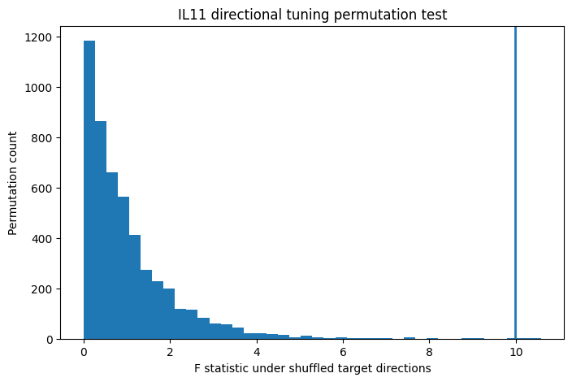

```python
N_PERMUTATIONS = 5000

observed = circular_direction_test(
    il11_hfb[
        il11_clean
    ],
    theta[
        il11_clean
    ],
)

null_f = []

clean_theta = theta[
    il11_clean
]

clean_hfb = il11_hfb[
    il11_clean
]

for _ in range(
    N_PERMUTATIONS
):
    shuffled_theta = RNG.permutation(
        clean_theta
    )

    result = circular_direction_test(
        clean_hfb,
        shuffled_theta,
    )

    null_f.append(
        result["F"]
    )

null_f = np.asarray(
    null_f
)

empirical_p = (
    1
    + np.sum(
        null_f
        >= observed["F"]
    )
) / (
    N_PERMUTATIONS
    + 1
)

print(
    f"Observed F: {observed['F']:.3f}"
)

print(
    f"Parametric p: {observed['p']:.6g}"
)

print(
    f"Permutation p: {empirical_p:.6g}"
)

fig, ax = plt.subplots(
    figsize=(8, 5)
)

ax.hist(
    null_f[
        np.isfinite(
            null_f
        )
    ],
    bins=40,
)

ax.axvline(
    observed["F"],
    linewidth=2,
)

ax.set_xlabel(
    "F statistic under shuffled target directions"
)

ax.set_ylabel(
    "Permutation count"
)

ax.set_title(
    "IL11 directional tuning permutation test"
)

plt.show()
```

# Part G: Spatial specificity around IL11

This examines direction tuning across all contacts on the IL shaft.

A sharply localized maximum near IL11 is more supportive of a local neural effect than equally strong tuning across the entire shaft.

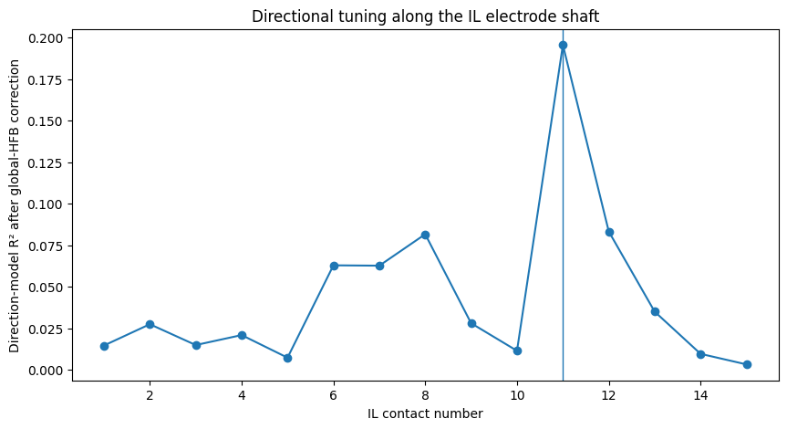

|  | channel_name | contact | F | p | r2 | preferred_direction_deg |
| --- | --- | --- | --- | --- | --- | --- |
| 0 | IL1 | 1 | 0.570618 | 0.567548 | 0.014605 | 38.031600 |
| 1 | IL2 | 2 | 1.085863 | 0.342723 | 0.027431 | 12.288392 |
| 2 | IL3 | 3 | 0.581842 | 0.561306 | 0.014888 | 353.916184 |
| 3 | IL4 | 4 | 0.821600 | 0.443545 | 0.020894 | 112.820611 |
| 4 | IL5 | 5 | 0.282402 | 0.754748 | 0.007282 | 201.567350 |
| 5 | IL6 | 6 | 2.583865 | 0.082015 | 0.062892 | 168.689659 |
| 6 | IL7 | 7 | 2.574829 | 0.082712 | 0.062686 | 147.668912 |
| 7 | IL8 | 8 | 3.422103 | 0.037686 | 0.081630 | 138.014501 |
| 8 | IL9 | 9 | 1.110380 | 0.334650 | 0.028033 | 119.070639 |
| 9 | IL10 | 10 | 0.445436 | 0.642185 | 0.011437 | 197.382641 |
| 10 | IL11 | 11 | 9.362071 | 0.000229 | 0.195605 | 186.359377 |
| 11 | IL12 | 12 | 3.495890 | 0.035219 | 0.083244 | 180.066466 |
| 12 | IL13 | 13 | 1.396109 | 0.253754 | 0.034994 | 157.402254 |
| 13 | IL14 | 14 | 0.372798 | 0.690040 | 0.009590 | 137.709718 |
| 14 | IL15 | 15 | 0.125023 | 0.882656 | 0.003237 | 289.487069 |

```python
il_contacts = (
    intracranial_channels.loc[
        intracranial_channels[
            "electrode"
        ] == "IL"
    ]
    .sort_values(
        "contact"
    )
    .reset_index(drop=True)
)

il_direction_rows = []

for _, contact_row in il_contacts.iterrows():
    pos = channel_position(
        contact_row[
            "channel_name"
        ]
    )

    result = circular_direction_test(
        hfb[
            :,
            pos,
        ]
        - global_hfb,
        theta,
    )

    il_direction_rows.append({
        "channel_name": contact_row[
            "channel_name"
        ],
        "contact": contact_row[
            "contact"
        ],
        **result,
    })

il_direction_table = pd.DataFrame(
    il_direction_rows
)

fig, ax = plt.subplots(
    figsize=(10, 5)
)

ax.plot(
    il_direction_table[
        "contact"
    ],
    il_direction_table[
        "r2"
    ],
    marker="o",
)

ax.axvline(
    11,
    linewidth=1,
)

ax.set_xlabel(
    "IL contact number"
)

ax.set_ylabel(
    "Direction-model R² after global-HFB correction"
)

ax.set_title(
    "Directional tuning along the IL electrode shaft"
)

plt.show()

display(
    il_direction_table
)
```

## G1. IL11 adjacent bipolar pairs

The two local bipolar signals are:

- IL11 - IL10
- IL12 - IL11

Directional tuning is tested on each.

```python
il11_minus_il10 = (
    trial_hfb_for_1d_signal(
        bipolar_signal(
            "IL11",
            "IL10",
        )
    )
)

il12_minus_il11 = (
    trial_hfb_for_1d_signal(
        bipolar_signal(
            "IL12",
            "IL11",
        )
    )
)

bipolar_direction_rows = []

for pair_name, values in {
    "IL11-IL10": il11_minus_il10,
    "IL12-IL11": il12_minus_il11,
}.items():
    result = circular_direction_test(
        values,
        theta,
    )

    bipolar_direction_rows.append({
        "pair": pair_name,
        **result,
    })

display(
    pd.DataFrame(
        bipolar_direction_rows
    )
)
```

|  | pair | F | p | r2 | preferred_direction_deg |
| --- | --- | --- | --- | --- | --- |
| 0 | IL11-IL10 | 7.825122 | 0.000806 | 0.168917 | 181.930758 |
| 1 | IL12-IL11 | 16.241357 | 0.000001 | 0.296693 | 178.604229 |

# Part H: Plot individual suspicious and representative trials

The most extreme raw-amplitude trials and strongest HFB trials are plotted for each interesting channel.

This is useful for visually checking whether the statistical relationships are driven by:

- a single spike
- amplifier clipping
- a DC step
- a burst of line noise
- a movement artifact

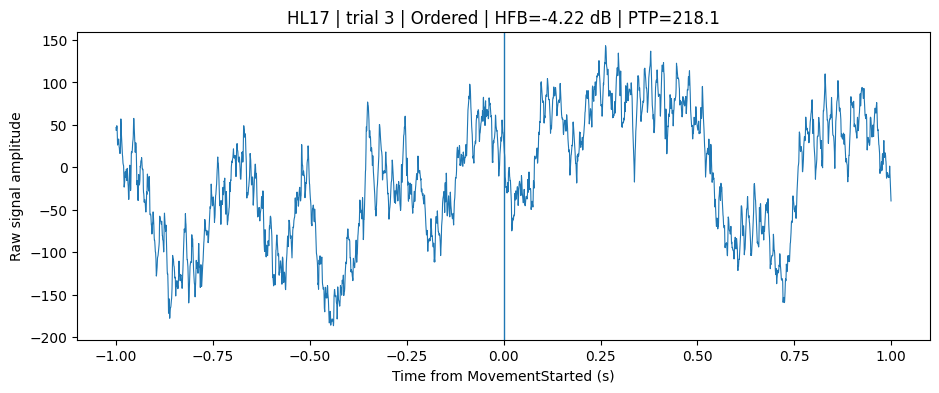

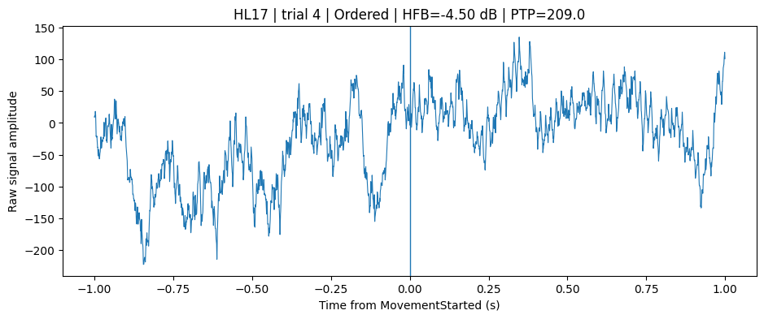

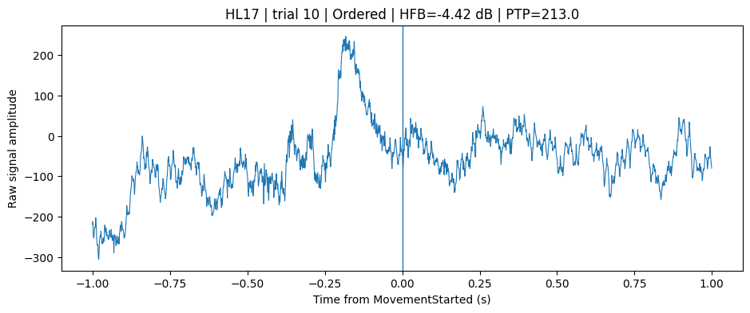

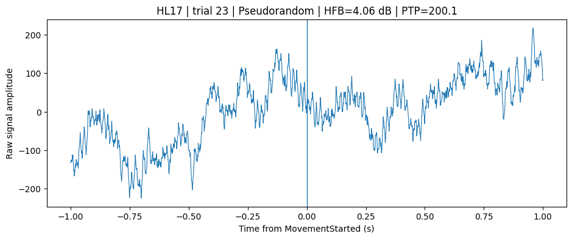

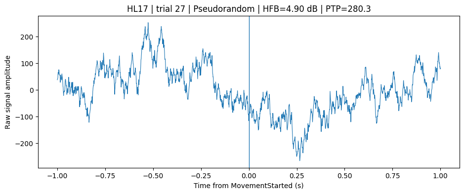

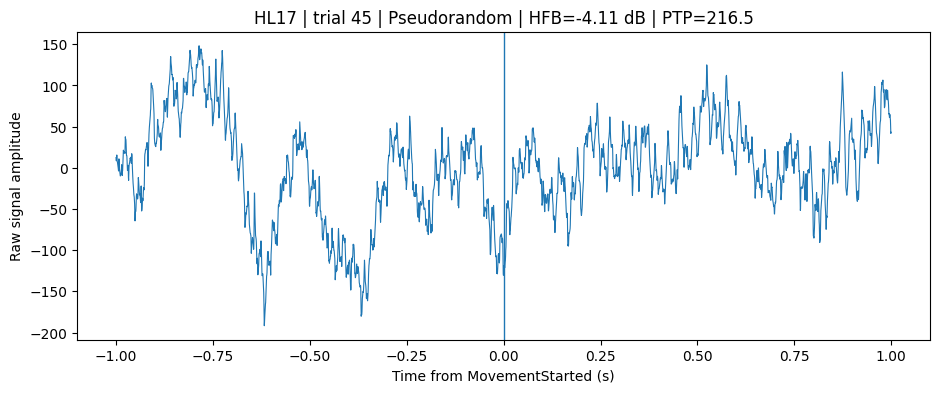

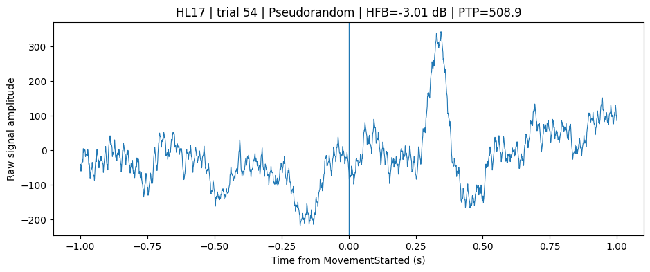

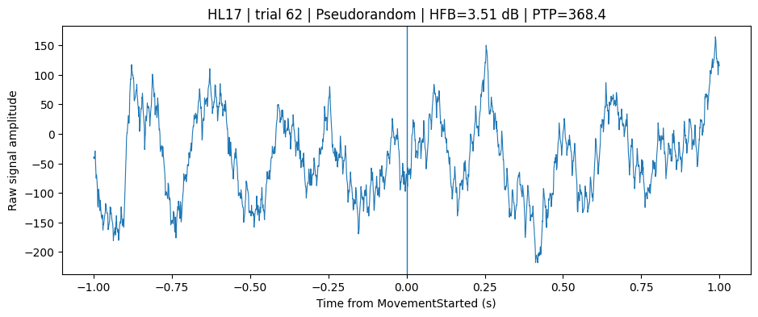

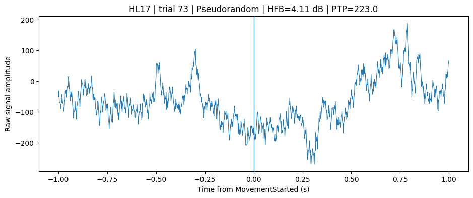

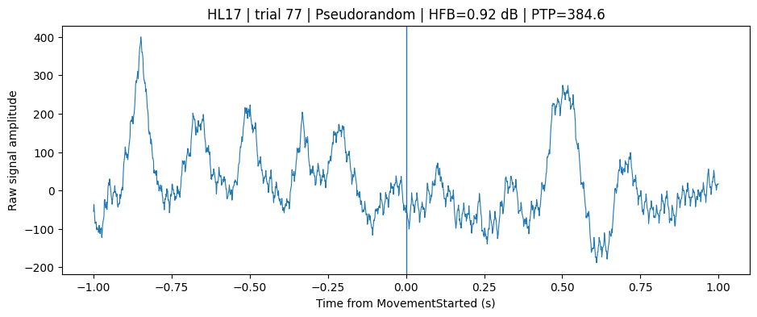

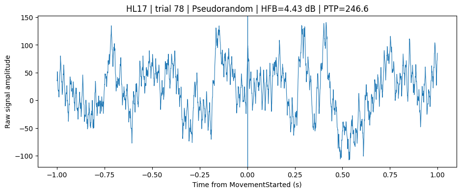

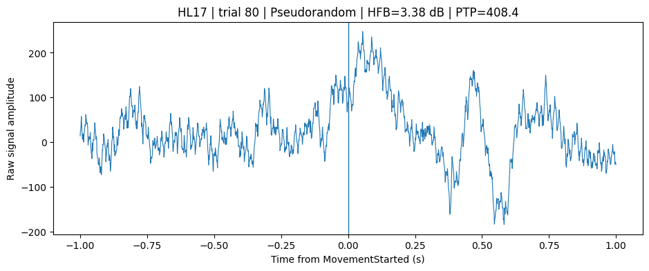

[12 more figures not shown]

```python
def plot_selected_raw_trials(
    channel_name,
    signal_index,
    position,
    n_each=4,
):
    raw_trials, kept = (
        extract_raw_event_trials(
            signal_index
        )
    )

    hfb_values = hfb[
        kept,
        position,
    ]

    ptp_values = movement_ptp[
        kept,
        position,
    ]

    strongest_hfb = np.argsort(
        hfb_values
    )[
        -n_each:
    ]

    weakest_hfb = np.argsort(
        hfb_values
    )[
        :n_each
    ]

    largest_ptp = np.argsort(
        ptp_values
    )[
        -n_each:
    ]

    selected = np.unique(
        np.r_[
            strongest_hfb,
            weakest_hfb,
            largest_ptp,
        ]
    )

    for local_index in selected:
        trial_row = neural_trials.iloc[
            kept[
                local_index
            ]
        ]

        fig, ax = plt.subplots(
            figsize=(11, 4)
        )

        ax.plot(
            raw_times,
            raw_trials[
                local_index
            ],
            linewidth=0.8,
        )

        ax.axvline(
            0,
            linewidth=1,
        )

        ax.set_xlabel(
            "Time from MovementStarted (s)"
        )

        ax.set_ylabel(
            "Raw signal amplitude"
        )

        ax.set_title(
            f"{channel_name} | trial {int(trial_row['trial'])} | "
            f"{trial_row['context']} | "
            f"HFB={hfb_values[local_index]:.2f} dB | "
            f"PTP={ptp_values[local_index]:.1f}"
        )

        plt.show()


plot_selected_raw_trials(
    "HL17",
    HL17_SIGNAL_INDEX,
    HL17_POS,
)

plot_selected_raw_trials(
    "IL11",
    IL11_SIGNAL_INDEX,
    IL11_POS,
)
```

# Part I: Final evidence table

This cell summarizes the main robustness checks.

Interpretation should emphasize consistency across analyses rather than any one p-value.

```python
summary_rows = []

# HL17 simple context effect
simple_hl17_test = ttest_ind(
    hl17_hfb[
        pseudo_mask
    ],
    hl17_hfb[
        ordered_mask
    ],
    equal_var=False,
    nan_policy="omit",
)

summary_rows.append({
    "finding": "HL17 context effect, raw monopolar",
    "estimate": (
        np.nanmean(
            hl17_hfb[
                pseudo_mask
            ]
        )
        - np.nanmean(
            hl17_hfb[
                ordered_mask
            ]
        )
    ),
    "p_or_note": simple_hl17_test.pvalue,
})

# HL17 clean context effect
summary_rows.append({
    "finding": "HL17 context effect, artifact-excluded",
    "estimate": (
        np.nanmean(
            hl17_hfb[
                pseudo_clean
            ]
        )
        - np.nanmean(
            hl17_hfb[
                ordered_clean
            ]
        )
    ),
    "p_or_note": test_clean.pvalue,
})

# HL17 controlled regression
context_row = hl17_model.loc[
    hl17_model[
        "term"
    ] == "Pseudorandom_context"
].iloc[0]

summary_rows.append({
    "finding": "HL17 context coefficient after drift/global/behavior controls",
    "estimate": context_row[
        "coefficient"
    ],
    "p_or_note": context_row[
        "p"
    ],
})

# IL11 direction
summary_rows.append({
    "finding": "IL11 direction tuning, artifact-excluded",
    "estimate": observed[
        "r2"
    ],
    "p_or_note": empirical_p,
})

# IL11 controlled direction
summary_rows.append({
    "finding": "IL11 direction tuning after context/drift/global controls",
    "estimate": il11_controlled_direction[
        "r2"
    ],
    "p_or_note": il11_controlled_direction[
        "p"
    ],
})

# Bipolar checks
for pair_name, values in {
    "HL17-HL16": hl17_minus_hl16,
    "HL18-HL17": hl18_minus_hl17,
}.items():
    test = ttest_ind(
        values[
            pseudo_mask
        ],
        values[
            ordered_mask
        ],
        equal_var=False,
        nan_policy="omit",
    )

    summary_rows.append({
        "finding": f"{pair_name} context effect",
        "estimate": (
            np.nanmean(
                values[
                    pseudo_mask
                ]
            )
            - np.nanmean(
                values[
                    ordered_mask
                ]
            )
        ),
        "p_or_note": test.pvalue,
    })

for pair_name, values in {
    "IL11-IL10": il11_minus_il10,
    "IL12-IL11": il12_minus_il11,
}.items():
    result = circular_direction_test(
        values,
        theta,
    )

    summary_rows.append({
        "finding": f"{pair_name} direction tuning",
        "estimate": result[
            "r2"
        ],
        "p_or_note": result[
            "p"
        ],
    })

final_evidence = pd.DataFrame(
    summary_rows
)

display(
    final_evidence
)
```

|  | finding | estimate | p_or_note |
| --- | --- | --- | --- |
| 0 | HL17 context effect, raw monopolar | 2.065318 | 0.000109 |
| 1 | HL17 context effect, artifact-excluded | 2.125684 | 0.000073 |
| 2 | HL17 context coefficient after drift/global/be... | 0.625956 | 0.667292 |
| 3 | IL11 direction tuning, artifact-excluded | 0.205870 | 0.000600 |
| 4 | IL11 direction tuning after context/drift/glob... | 0.342041 | 0.000059 |
| 5 | HL17-HL16 context effect | 2.455505 | 0.000650 |
| 6 | HL18-HL17 context effect | 2.718407 | 0.002000 |
| 7 | IL11-IL10 direction tuning | 0.168917 | 0.000806 |
| 8 | IL12-IL11 direction tuning | 0.296693 | 0.000001 |

# How to interpret this notebook

## HL17 becomes more convincing if:

- raw movement-aligned traces do not show obvious spikes or clipping
- HFB does not strongly correlate with raw peak-to-peak or 120 Hz change
- the context coefficient remains significant after trial drift and global HFB are included
- the effect survives artifact-trial exclusion
- at least one adjacent bipolar pair preserves the context effect
- the effect is spatially localized around HL17 rather than equally large across the whole HL shaft

## IL11 becomes more convincing if:

- the fitted target circle agrees with `TargetAngle`
- the direction effect survives global-HFB correction
- the direction effect survives artifact-trial exclusion
- the permutation test remains significant
- the effect remains after context and recording drift are controlled
- at least one adjacent bipolar pair shows similar directional tuning
- the effect is spatially strongest around IL11 rather than uniform across the IL shaft

## Reasons to be cautious

- strong correlation between HFB and raw amplitude or 120 Hz changes
- obvious transient spikes or clipping on the selected raw trials
- disappearance after bipolar rereferencing
- a smooth drift across the recording that mimics the context switch
- nearly identical effects across an entire electrode shaft
- failure of the target-angle geometry check

The strongest evidence would be a result that is temporally aligned to behavior, spatially local, reference-resistant, artifact-resistant, and replicated across recordings or participants.